# Emission factor exploratory data analysis

2022-07-22

This Markdown explores the FAOmassbalance and Edgar Food data and calculates emission factors based on this data.

Do the basic data setup in below code chunk.

```r
library(mrcommons)
library(magrittr)
library(tidyverse)
library(rworldmap)

foodEmi <- readSource("EDGARfood", subtype="foodSystemSector")

foodBal <- calcOutput("FAOmassbalance", aggregate = F)

foodEmi <- toolCountryFill(foodEmi)

foodBal <- time_interpolate(foodBal, seq(1990,2018) )
```

In FAOmassbalance some years are missing, these are interpolated or extrapolated. In EDGARFood some countries are missing or not according to the current iso standart. This will result in NAs when calculating emission factors.

## Production

### Description

The emission factors for the production are calculated for each country (c) each year (y).
$$emissionFactorProd_{~c~y}=\frac{productionEmissions_{~c~y}}{nrProduction_{~c~y}}$$
**productionEmissions** is the EDGARfood data on the emissions of the production stage in the life-cycle of food products. It is composed of emissions from the agricultural land (fertilisation, drainage of soils, waste burning etc. ) as well as from the production of chemicals and solvents that are used for agricultural purposes (fertilizer, plastic, pesticides etc.) (Crippa,M et al p. 205-206). All GHG substances (CO_2 , CH_4 , N_2O, fluorinated gases; all in kt co2eq) are summed. The unit is converted to mt co2eq.

**nrProduction** is the FAOmassbalance data on reactive nitrogen (nr) production of the food system of each country.

The calculations are carried out below.

```r
# prepare the source data
emiFacProd <-
  mbind(dimSums(foodEmi[,,"Production"], "Substance")*(10^-3),      # productionEmission
        # take emssions form all substances combined
        dimSums(foodBal[,,"production.nr"], dim= "ItemCodeItem")%>% # nrProduction
            collapseDim( dim=3.1)
        # take nr production output of all items combined

       )

getItems(emiFacProd, dim=3) <- c("emissions", "nrproduction")

# calculate the emission factor
Fac <- ifelse( emiFacProd[,,"nrproduction"]>0, emiFacProd[,,"emissions"]/ emiFacProd[,,"nrproduction"], NaN)

getItems(Fac, dim=3) <- c("emissionFactorProd")

emiFacProd <- mbind(emiFacProd, Fac)
```

### NAs

Check how many NAs are introduced in 2010

```r
cat("Total NAs introduced: ")
```

```
## Total NAs introduced:
```

```r
emiFacProd[,"y2010","emissionFactorProd"] %>% is.na %>% sum() %>% cat(.,"\n")
```

```
## 64
```

```r
cat("Number of cuntries where emissions is NA: ")
```

```
## Number of cuntries where emissions is NA:
```

```r
emiFacProd[,"y2010","emissions"] %>% is.na %>% sum() %>% cat(.,"\n")
```

```
## 30
```

```r
cat("Number of cuntries where nrproduction is zero: ")
```

```
## Number of cuntries where nrproduction is zero:
```

```r
(emiFacProd[,"y2010","nrproduction"]==0) %>% sum() %>% cat(.,"\n")
```

```
## 60
```

### Tables

Explore the object for 1990 in a table. Click on the column names to change row sorting.

```r
emiFacProd[,"y1990",] %>% as.data.frame() %>%
  pivot_wider(id_cols = "Region",names_from = "Data1", values_from = "Value" ) %>% DT::datatable(.)
```

|  | Region | emissions | nrproduction | emissionFactorProd |
| --- | --- | --- | --- | --- |
| 1 | ABW | 0.0121439813566757 | 0 |  |
| 2 | AFG | 8.893213690927 | 0.3881315337807 | 22.912886268993 |
| 3 | AGO | 5.47030157744079 | 0.157683937156772 | 34.6915587984218 |
| 4 | AIA | 4.32912585928995e-06 | 0 |  |
| 5 | ALA |  | 0 |  |
| 6 | ALB | 3.54508339713163 | 0.077506420749185 | 45.7392221555904 |
| 7 | AND |  | 0 |  |
| 8 | ARE | 1.82742745360207 | 0.0336820434278395 | 54.2552430798078 |
| 9 | ARG | 139.085489189042 | 4.5407216566216 | 30.6307013965979 |
| 10 | ARM | 3.21013254974159 | 0.0762966127580216 | 42.0743783203414 |

[output cut: 239 more lines]

For 2010

```r
emiFacProd[,"y2010",] %>% as.data.frame() %>%
  pivot_wider(id_cols = "Region",names_from = "Data1", values_from = "Value" ) %>% DT::datatable(.)
```

|  | Region | emissions | nrproduction | emissionFactorProd |
| --- | --- | --- | --- | --- |
| 1 | ABW | 0.0367744843062353 | 0 |  |
| 2 | AFG | 16.4320089445638 | 0.64319641956073 | 25.5474198002936 |
| 3 | AGO | 9.13790382906934 | 0.247587337670916 | 36.9077995467405 |
| 4 | AIA | 1.60345565293117e-05 | 0 |  |
| 5 | ALA |  | 0 |  |
| 6 | ALB | 2.85044142762399 | 0.0889411781759568 | 32.048613320422 |
| 7 | AND |  | 0 |  |
| 8 | ARE | 3.30473080302773 | 0.0682212418103179 | 48.4413756673647 |
| 9 | ARG | 159.413541348075 | 8.89214429124947 | 17.9274577792164 |
| 10 | ARM | 1.68260638636125 | 0.0656798457378916 | 25.6183060032758 |

[output cut: 239 more lines]

### Plots

Plot the emission factors to get a quick spatial overview. In order to get the high values into the picture but capture display variance in the low values a log scaling for the colors is used.

```
## 237 codes from your data successfully matched countries in the map
## 12 codes from your data failed to match with a country code in the map
## 6 codes from the map weren't represented in your data
```

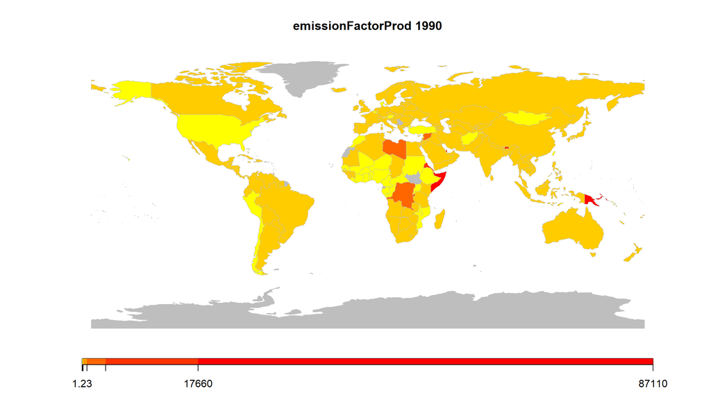

```r
{m <- luplot::plotcountrymap(emiFacProd[,"y1990","emissionFactorProd"], catMethod="logFixedWidth",  missingCountryCol = "gray", addLegend=FALSE)
do.call( addMapLegend, c( m
                          , legendLabels="all"
                          , legendWidth=0.5
))}
```

```
## 237 codes from your data successfully matched countries in the map
## 12 codes from your data failed to match with a country code in the map
## 6 codes from the map weren't represented in your data
```

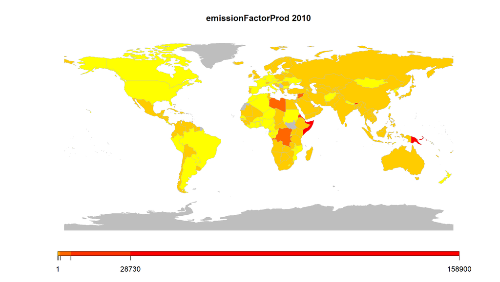

```r
{m <- luplot::plotcountrymap(emiFacProd[,"y2010","emissionFactorProd"], catMethod="logFixedWidth",  missingCountryCol = "gray", addLegend=FALSE)
do.call( addMapLegend, c( m
                          , legendLabels="all"
                          , legendWidth=0.5
))}
```

## Processing

### Description

The emission factors for the production are calculated for each country (c) each year (y).
$$emissionFactorProcc_{~c~y}=\frac{processingEmissions_{~c~y}}{nrProcessing_{~c~y}}$$
**processingEmissions** is the EDGARfood data on the emissions of the processing stage in the life-cycle of food products. This includes the emissions from combustion in the food and tobacco processing industry. (Crippa, M et al p. 206) All GHG substances (CO_2 , CH_4 , N_2O, fluorinated gases; all in kt co2eq) are summed. The unit is converted to mt co2eq.

**nrProcessing** is based on the FAOmassbalance data on nr output of different processing economies of each country.

```r
# prepare the source data
emiFacProcc <-
  mbind(dimSums(foodEmi[,,"Processing"], "Substance")*(10^-3), #processingEmissions
        dimSums(foodBal[,,
                        c("food", "milling", "refining" ,
                          "extracting" , "fermentation",
                          "distilling") ][,,"nr"],
                dim= c("ItemCodeItem", "ElementShort") ) #nrProcessing
       )

getItems(emiFacProcc, dim=3) <- c("emissions", "nrprocessing")

# calculate the emission factor
Fac <- ifelse( emiFacProcc[,,"nrprocessing"]>0, emiFacProcc[,,"emissions"]/ emiFacProcc[,,"nrprocessing"], NaN)

getItems(Fac, dim=3) <- c("emissionFactorProcc")

emiFacProcc <- mbind(emiFacProcc, Fac)
```

### NAs

NAs introduced in 2010

```r
cat("Total NAs introduced: ")
```

```
## Total NAs introduced:
```

```r
emiFacProcc[,"y2010","emissionFactorProcc"] %>% is.na %>% sum() %>% cat(.,"\n")
```

```
## 77
```

```r
cat("Number of countries where emissions is NA: ")
```

```
## Number of countries where emissions is NA:
```

```r
emiFacProcc[,"y2010","emissions"] %>% is.na %>% sum() %>% cat(.,"\n")
```

```
## 30
```

```r
cat("Number of countries where nrprocessing is zero: ")
```

```
## Number of countries where nrprocessing is zero:
```

```r
(emiFacProcc[,"y2010","nrprocessing"]==0) %>% sum() %>% cat(.,"\n")
```

```
## 75
```

### Tables

Explore the object for 1990.

```r
emiFacProcc[,"y1990",] %>% as.data.frame() %>%
  pivot_wider(id_cols = "Region",names_from = "Data1", values_from = "Value" ) %>% DT::datatable(.)
```

|  | Region | emissions | nrprocessing | emissionFactorProcc |
| --- | --- | --- | --- | --- |
| 1 | ABW | 0.00253004078748116 | 0 |  |
| 2 | AFG | 0.028947704509931 | 0.05834722954012 | 0.49612817503231 |
| 3 | AGO | 0.262562846128991 | 0.0283349808812179 | 9.26638515232007 |
| 4 | AIA | 4.79418124080262e-06 | 0 |  |
| 5 | ALA |  | 0 |  |
| 6 | ALB | 0.194733036785817 | 0.0211617398323067 | 9.20212791240001 |
| 7 | AND |  | 0 |  |
| 8 | ARE | 0.497468843797875 | 0.0130853329801935 | 38.0172858077715 |
| 9 | ARG | 2.23511850385102 | 0.711939471978444 | 3.1394782728365 |
| 10 | ARM | 0.0770659735068417 | 0.0192002032108423 | 4.01381030505566 |

[output cut: 239 more lines]

For 2010.

```r
emiFacProcc[,"y2010",] %>% as.data.frame() %>%
  pivot_wider(id_cols = "Region",names_from = "Data1", values_from = "Value" ) %>% DT::datatable(.)
```

|  | Region | emissions | nrprocessing | emissionFactorProcc |
| --- | --- | --- | --- | --- |
| 1 | ABW | 0.00791553538875906 | 0 |  |
| 2 | AFG | 0.0556730261066583 | 0.126651548741264 | 0.439576354651552 |
| 3 | AGO | 0.494696582097978 | 0.0820006438629109 | 6.03283777777421 |
| 4 | AIA | 1.10521336398556e-05 | 0 |  |
| 5 | ALA |  | 0 |  |
| 6 | ALB | 0.166887062996678 | 0.028603561975805 | 5.83448533919809 |
| 7 | AND |  | 0 |  |
| 8 | ARE | 1.29597938427764 | 0.0857556296285258 | 15.1124700488065 |
| 9 | ARG | 7.041621641456 | 2.44225061769562 | 2.88325104329387 |
| 10 | ARM | 0.039354752288942 | 0.0193343956247594 | 2.03547879399679 |

[output cut: 239 more lines]

### Plots

Plot the emission factors to get a quick spatial overview. A linear scaling for the colors is used.

```
## 237 codes from your data successfully matched countries in the map
## 12 codes from your data failed to match with a country code in the map
## 6 codes from the map weren't represented in your data
```

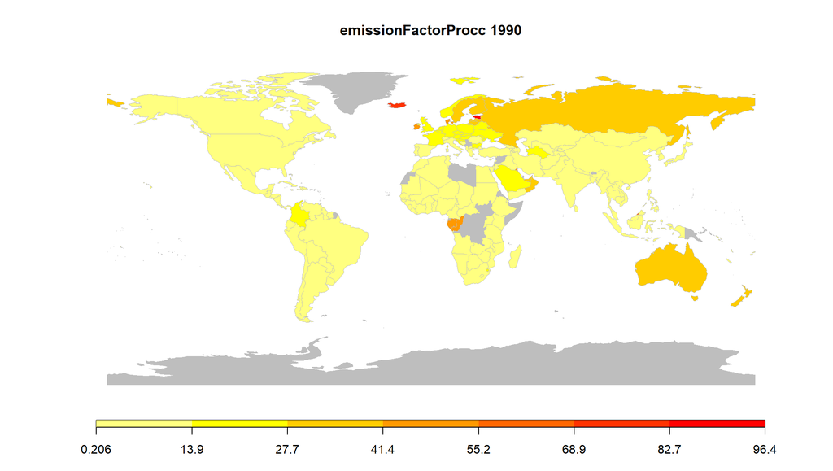

```r
{m <- luplot::plotcountrymap(emiFacProcc[,"y1990","emissionFactorProcc"], catMethod="fixedWidth",  missingCountryCol = "gray", addLegend=FALSE)
do.call( addMapLegend, c( m
                          , legendLabels="all"
                          , legendWidth=0.5
))}
```

```
## 237 codes from your data successfully matched countries in the map
## 12 codes from your data failed to match with a country code in the map
## 6 codes from the map weren't represented in your data
```

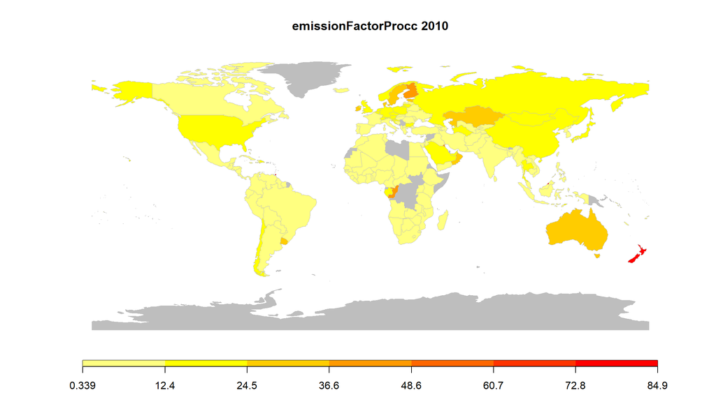

```r
{m <- luplot::plotcountrymap(emiFacProcc[,"y2010","emissionFactorProcc"], catMethod="fixedWidth",  missingCountryCol = "gray", addLegend=FALSE)
do.call( addMapLegend, c( m
                          , legendLabels="all"
                          , legendWidth=0.5
))}
```